# Human Cervix Organoids - QC and data preprocessing

Hilmar Berger

04 November, 2020 18:38:16

```r
rm(list=ls())
library(limma)
library(pheatmap)
library(xtable)
library(readxl)
```

```r
ed = as.data.frame(read_excel("../../Data/SampleDecriptions/Human/ExpDesign.xls", sheet = 1), stringsAsFactors=F)
colnames(ed) = make.names(colnames(ed))

ed$sample_ID = ed$scan_id
ed$ShortName = paste(ed$Tissue.Type,"_",ifelse(ed$Tissue.Status=="Normal", "", paste("_",ed$Tissue.Status,sep="")),"_", ed$Organoid.Type, sep="")

ed$filename_orig = ed$file_name

gsm_files = list.files("../../Data/Raw/Microarray/", pattern="*.txt")
tmp = strsplit(gsm_files,"_")
names(gsm_files) = unlist(sapply(tmp, function(x) paste(x[2:length(x)],collapse="_")))
ed$file_name = gsm_files[ed$file_name]

rownames(ed) = gsub(".txt","",ed$file_name)
setwd("../../Data/Raw/Microarray/")
agilent.datacolumns=list(E='gMedianSignal',Eb = 'gBGMedianSignal',isNonUniform='gIsFeatNonUnifOL', isPopOutlier='gIsFeatPopnOL', multDetrendSignal='gMultDetrendSignal');
intensities =read.maimages(paste(ed$file_name,sep=""), source="agilent.median", green.only=TRUE, columns=agilent.datacolumns)
```

```
## Read GSM2321727_US22502595_254890810423_S01_GE1_1105_Oct12_1_1.txt
## Read GSM2321728_US22502595_254890810423_S01_GE1_1105_Oct12_1_2.txt
## Read GSM2321729_US22502595_254890810423_S01_GE1_1105_Oct12_2_2.txt
## Read GSM2321730_US22502595_254890810423_S01_GE1_1105_Oct12_2_3.txt
## Read GSM2321731_US22502595_254890810568_S01_GE1_1105_Oct12_1_1.txt
## Read GSM2321732_US22502595_254890810568_S01_GE1_1105_Oct12_1_3.txt
## Read GSM2321733_US22502595_254890810568_S01_GE1_1105_Oct12_2_1.txt
## Read GSM2321734_US22502595_254890810570_S01_GE1_1105_Oct12_1_3.txt
## Read GSM2321735_US22502595_254890810570_S01_GE1_1105_Oct12_1_4.txt
## Read GSM2321736_US22502595_254890810570_S01_GE1_1105_Oct12_2_1.txt
## Read GSM2321737_US22502595_254890810570_S01_GE1_1105_Oct12_2_2.txt
## Read GSM2321738_US22502595_254890810570_S01_GE1_1105_Oct12_2_3.txt
## Read GSM2321739_US22502595_254890810570_S01_GE1_1105_Oct12_2_4.txt
## Read GSM2321740_US22502595_254890810408_S01_GE1_1105_Oct12_1_2.txt
## Read GSM2321741_US22502595_254890810408_S01_GE1_1105_Oct12_1_3.txt
## Read GSM2321742_US22502595_254890810408_S01_GE1_1105_Oct12_1_4.txt
```

```r
setwd("../../../Code/Human")

# fix outdated chip annotations
new_anno_file = "../../Data/Raw/Microarray/Custom_60k_annotations_2015-05-22.Rdata"
load(new_anno_file)
old_anno = intensities$genes
take_over_cols = colnames(old_anno)[!colnames(old_anno) %in% c("GeneName","Description","SystematicName")]
tmp = old_anno[,take_over_cols]
tmp$index=1:nrow(tmp)
tmp = merge(tmp, anno_tab_final, by="ProbeName", all.x=T, sort=F)
new_col_order = c(take_over_cols, colnames(tmp)[!colnames(tmp) %in% take_over_cols])
new_col_order = new_col_order[!new_col_order %in% c("GO_BP","GO_CC","GO_MF")]
new_anno = tmp[order(tmp$index),new_col_order]

intensities$genes = new_anno
```

```r
intensities$probe_exclude=(intensities$isNonUniform>0)|(intensities$isPopOutlier>0)
intensities$E[intensities$probe_exclude] <- NA
```

# 1 Data overview

This document describes the preprocessing and QC of microarray data from human cervix samples (Rajendra Kumar, Cindrilla Chumduri). Micro arrays used had design 048908_D (custom 60K based on Sure G3 v2 + lincRNA from v1 and v2, defined by H.Mollenkopf, MPIIB).

## 1.1 Samples

```r
ed_short = ed[,c("scan_id","Sample.Name","Tissue.Type","Media","Forskilin","Organoid.Type","patient_or_mouse_id")]
print.xtable(xtable(ed_short,display=c("s","s","s","s","s","s","s","s"), align="|l|l|l|l|l|l|l|l|"), type="html", file="" , include.rownames=F)
```

| scan_id | Sample.Name | Tissue.Type | Media | Forskilin | Organoid.Type | patient_or_mouse_id |
| --- | --- | --- | --- | --- | --- | --- |
| H1 | Ecto-Whole Organoid (M5+FSK) | Ecto | M5 | +FSK | Whole Organoid | hc029 |
| H2 | Endo-Whole Organoids (M1.7-FSK) | Endo | M1.7 | -FSK | Whole Organoid | hc034 |
| H6 | 3 days Post splitting -EctoOrganoids (M5+FSK) | Ecto | M5 | +FSK | EarlyOrganoids | hc036 |
| H7 | Ecto-WholeOrganoids (M5+FSK) | Ecto | M5 | +FSK | Whole Organoid | hc036 |
| H9 | hC040-Ecto-2DP1 (M5+FSK)+Uninfected (36hpi)-Replicate1 | Ecto | M5 | +FSK | 2D | hc040 |
| H11 | hC037-Ecto-2DP2 (M5+FSK)+ Uninfected (36hpi)-Replicate2 | Ecto | M5 | +FSK | 2D | hc037 |
| H13 | hC040-Ecto-2DP2 (M5+FSK)+Uninfected (36hpi)-Replicate3 | Ecto | M5 | +FSK | 2D | hc040 |
| H27 | hC042-Endo-2DP0(M1.7-FSK) to 3DP0 (M1.7-FSK) | Endo | M1.7 | -FSK | Whole Organoid | hc042 |
| H28 | hC045-Endo-2DP0 (M1.7-FSK) to 3DP0 (M1.7-FSK) | Endo | M1.7 | -FSK | Whole Organoid | hc045 |
| H29 | hC040-Ecto-2DP1(M5+FSK)-3DP1(M5+FSK)-Early organoids (3Days) | Ecto | M5 | +FSK | EarlyOrganoids | hc040 |
| H30 | hC040-Ecto-2DP1(M5+FSK)-3DP1(M5+FSK)-Whole organoids (3Days) | Ecto | M5 | +FSK | Whole Organoid | hc040 |
| H31 | hC047-Ecto-2DP0 (M5+FSK) to 3DP0 (M5+FSK)-Early organoids (3 Days) | Ecto | M5 | +FSK | EarlyOrganoids | hc047 |
| H32 | hC047-Ecto-2DP0 (M5+FSK) to 3DP0 (M5+FSK)- Whole Organoid (12 Days) | Ecto | M5 | +FSK | Whole Organoid | hc047 |
| H33 | hC042-Endo-2DP1(M1.7-FSK) | Endo | M1.7 | -FSK | 2D | hc042 |
| H34 | hc045-Endo-2DP0 (M1.7-FSK) | Endo | M1.7 | -FSK | 2D | hc045 |
| H35 | hC048-Endo-2Dp0 (M1.7-FSK) | Endo | M1.7 | -FSK | 2D | hc048 |

## 1.2 Raw intensity data

### 1.2.1 Excluded probes (non-uniform feature or population outlier)

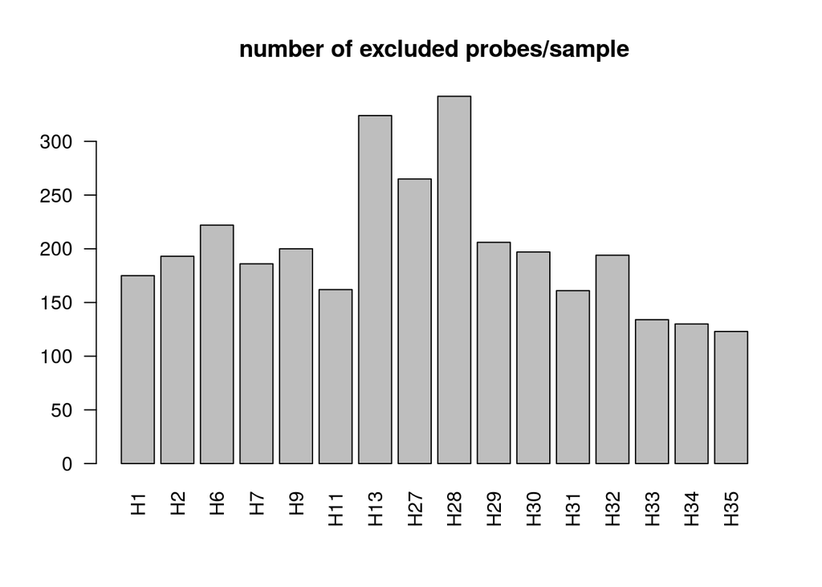

```r
ex_cnt = apply(intensities$probe_exclude,2,sum)
barplot(ex_cnt, las=2, names.arg = ed[names(ex_cnt),]$sample_ID, main = "number of excluded probes/sample")
```

### 1.2.2 Intensity distribution across samples

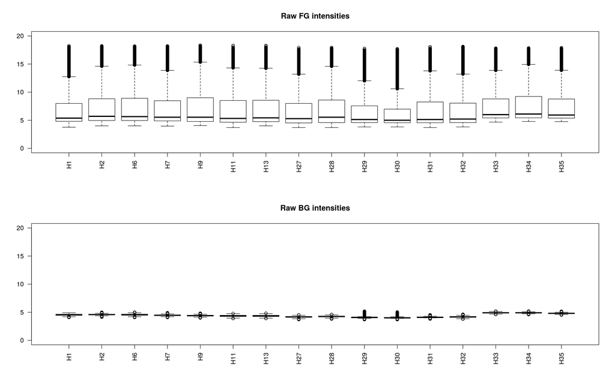

```r
par(mfrow=c(2,1))
ii = log2(intensities$E)
colnames(ii) = ed[colnames(ii),]$sample_ID
boxplot(ii, las=2, main = "Raw FG intensities", ylim=c(0,20))
ii = log2(intensities$Eb)
colnames(ii) = ed[colnames(ii),]$sample_ID
boxplot(ii, las=2, main = "Raw BG intensities", ylim=c(0,20))
```

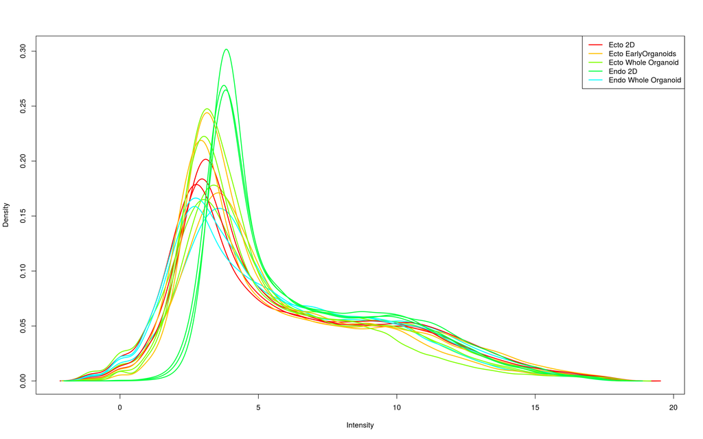

```r
par(mfrow=c(1,1))
plotDensities(intensities, legend="topright", group=paste(ed[colnames(intensities$E),"Tissue.Type"], ed[colnames(intensities$E),"Organoid.Type"]))
```

### 1.2.3 Correlation of raw intensities across samples

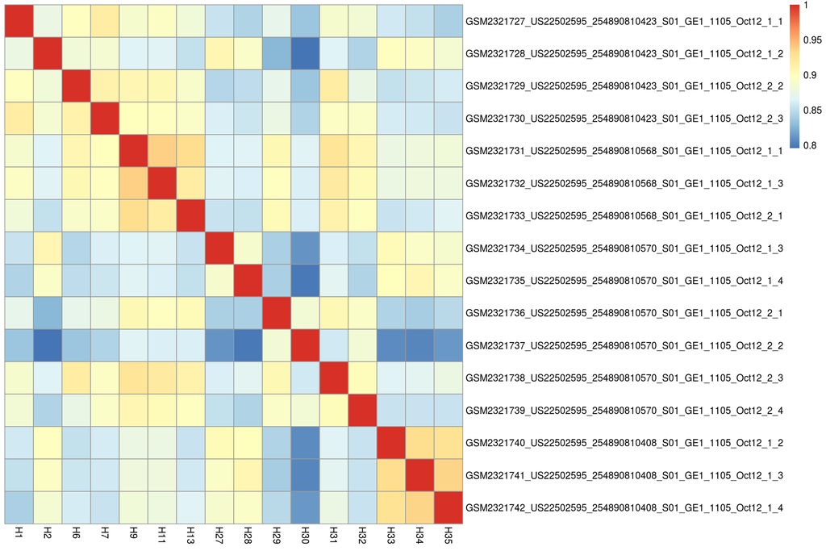

```r
raw_cor = cor(log2(intensities$E),method="spearman", use="pairwise")
colnames(raw_cor) = ed[colnames(raw_cor),]$sample_ID
#rownames(raw_cor) = ed[rownames(raw_cor),]$sample_ID
pheatmap(raw_cor, cluster_rows = F, cluster_cols=F)
```

# 2 Preprocessing

Data will be preprocessed as follows:

- Background for each array will be corrected using the "normexp" method (Ritchie et al 2007, Bioinformatics, p. 2700-07) and an offset of 15.
- Between-array normalization will be perfomed using the quantile method (Bolstad et al 2003, Bioinformatics, p. 185).

## 2.1 Background correction

```r
bg_corrected = backgroundCorrect(intensities,method="normexp",offset=15)
```

```
## Array 1 corrected
## Array 2 corrected
## Array 3 corrected
## Array 4 corrected
## Array 5 corrected
## Array 6 corrected
## Array 7 corrected
## Array 8 corrected
## Array 9 corrected
## Array 10 corrected
## Array 11 corrected
## Array 12 corrected
## Array 13 corrected
## Array 14 corrected
## Array 15 corrected
## Array 16 corrected
```

### 2.1.1 Intensity distribution across samples after background correction

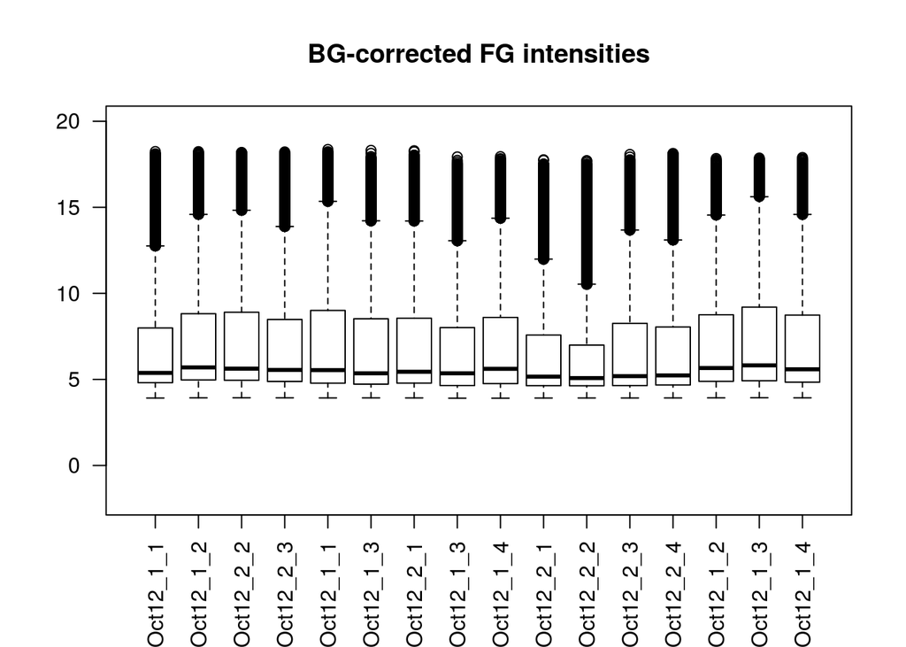

```r
boxplot(log2(bg_corrected$E), las=2, main = "BG-corrected FG intensities", ylim=c(-2,20))
```

## 2.2 Normalization

```r
normalized = normalizeBetweenArrays(bg_corrected,method="quantile")
```

### 2.2.1 Intensity distribution across samples after BG correction and normalization

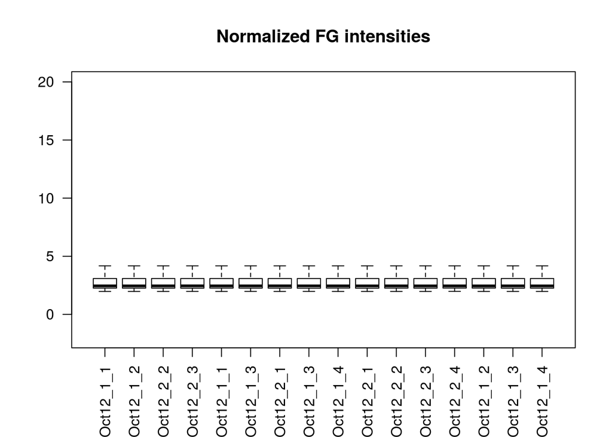

```r
boxplot(log2(normalized$E), las=2, main = "Normalized FG intensities", ylim=c(-2,20))
```

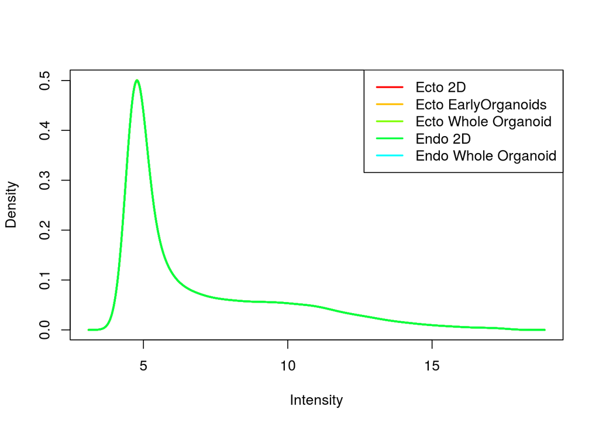

```r
par(mfrow=c(1,1))
plotDensities(normalized, legend="topright", group=paste(ed[colnames(intensities$E),"Tissue.Type"], ed[colnames(normalized$E),"Organoid.Type"]))
```

### 2.2.2 Correlation of normalized intensities across samples

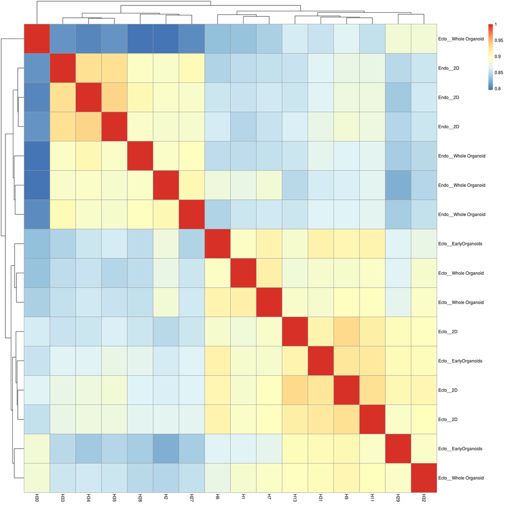

```r
norm_cor = cor(log2(normalized$E),method="spearman", use="pairwise")
colnames(norm_cor) = ed[colnames(norm_cor),]$sample_ID
rownames(norm_cor) = ed[rownames(norm_cor),]$ShortName
pheatmap(norm_cor)
```

# 3 Primary Component Analysis

## 3.1 PCA on all genes

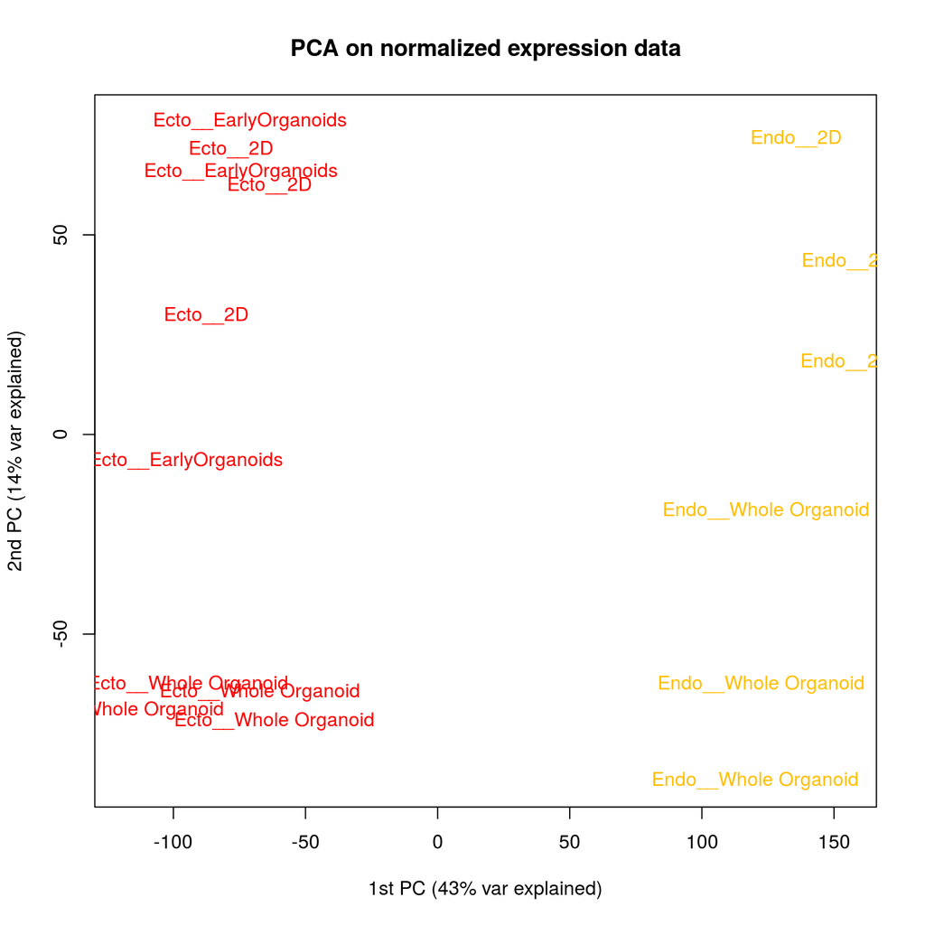

```r
norm_exp = normalized$E
NA_rows = apply(norm_exp,1,function(x) sum(is.na(x)))
pca = prcomp(t(norm_exp[NA_rows==0,]))
imp = summary(pca)$importance
plot(pca$x[,1], pca$x[,2], type="n", xlab=paste("1st PC (",round(imp[2,1],2)*100 ,"% var explained)",sep="" ), ylab=paste("2nd PC (",round(imp[2,2],2)*100 ,"% var explained)",sep="" ), main="PCA on normalized expression data")
cp = palette(rainbow(8))
text(pca$x[,1],pca$x[,2],labels=ed[colnames(normalized$E),]$ShortName, col=cp[as.numeric(as.factor(ed[colnames(normalized$E),]$Tissue.Type))])
```

## 3.2 PCA on most variable genes

Top 2000 genes with highest coefficient of variation are selected and used for PCA.

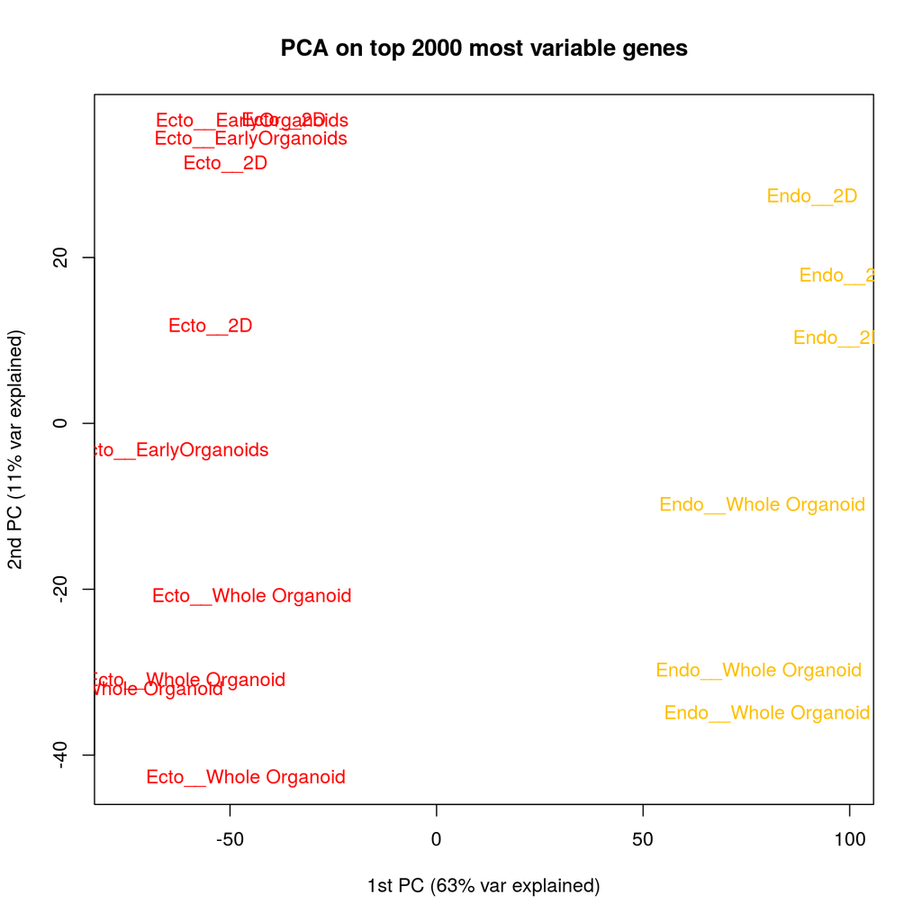

```r
mads = apply(normalized$E, 1, mad, na.rm=T)
medians = apply(normalized$E, 1, median, na.rm=T)
cofvar = mads/medians
top_2000 = ifelse(length(cofvar)-rank(cofvar) < 2000, T, F)
norm_exp = normalized$E[top_2000,]
NA_rows = apply(norm_exp,1,function(x) sum(is.na(x)))
pca = prcomp(t(norm_exp[NA_rows==0,]))
imp = summary(pca)$importance
plot(pca$x[,1], pca$x[,2], type="n", xlab=paste("1st PC (",round(imp[2,1],2)*100 ,"% var explained)",sep="" ), ylab=paste("2nd PC (",round(imp[2,2],2)*100 ,"% var explained)",sep="" ), main="PCA on top 2000 most variable genes")
cp = palette(rainbow(8))
text(pca$x[,1],pca$x[,2],labels=ed[colnames(normalized$E),]$ShortName, col=cp[as.numeric(as.factor(ed[colnames(normalized$E),]$Tissue.Type))])
```

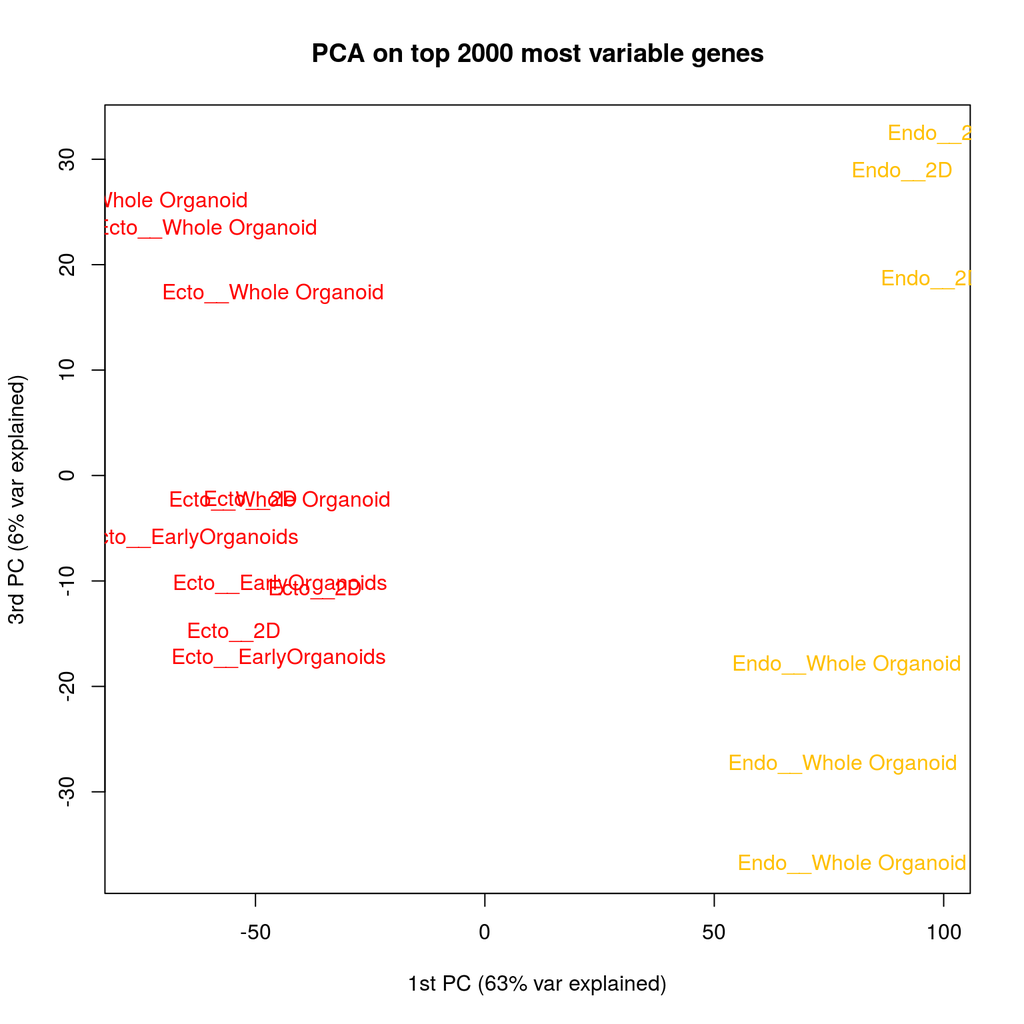

```r
plot(pca$x[,1], pca$x[,3], type="n", xlab=paste("1st PC (",round(imp[2,1],2)*100 ,"% var explained)",sep="" ), ylab=paste("3rd PC (",round(imp[2,3],2)*100 ,"% var explained)",sep="" ), main="PCA on top 2000 most variable genes")
cp = palette(rainbow(8))
text(pca$x[,1],pca$x[,3],labels=ed[colnames(normalized$E),]$ShortName, col=cp[as.numeric(as.factor(ed[colnames(normalized$E),]$Tissue.Type))])
```

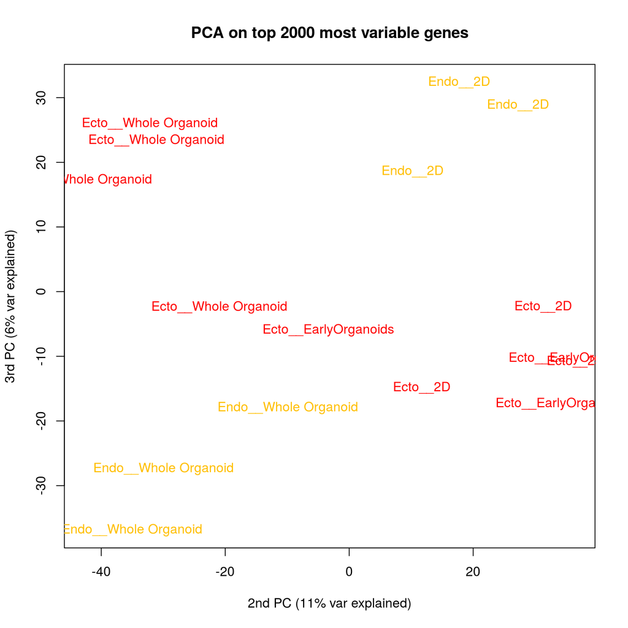

```r
plot(pca$x[,2], pca$x[,3], type="n", xlab=paste("2nd PC (",round(imp[2,2],2)*100 ,"% var explained)",sep="" ), ylab=paste("3rd PC (",round(imp[2,3],2)*100 ,"% var explained)",sep="" ), main="PCA on top 2000 most variable genes")
cp = palette(rainbow(8))
text(pca$x[,2],pca$x[,3],labels=ed[colnames(normalized$E),]$ShortName, col=cp[as.numeric(as.factor(ed[colnames(normalized$E),]$Tissue.Type))])
```

# 4 Control probes

The following control probes exist on the arrays used in this experiment:

- Corner associated (used for orientation purposes during scanning)
- Bright corner
- Dark corner
- Negative controls
- 3xSLv1 (hairpin probe that does not hybridize well with any possible RNA)
- Positive controls
- Human GAPDH and PGK1 probes
- Deletion stringency probes (DCP, probe with varying number of insertions/changes with respect to reference; the number after the "_" denotes the number of differences to the reference which should correlate with lower expression)
- E1A_r60: spike-in probes with concentrations that should cover the whole dynamic range of the array

There are a few other expression probes that are used by Agilent's feature extraction/QC pipeline.

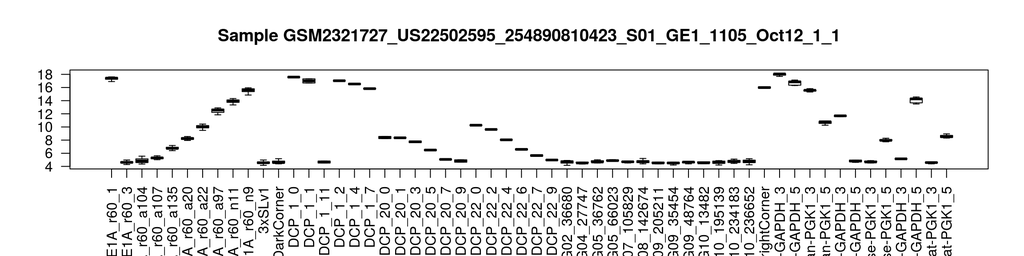

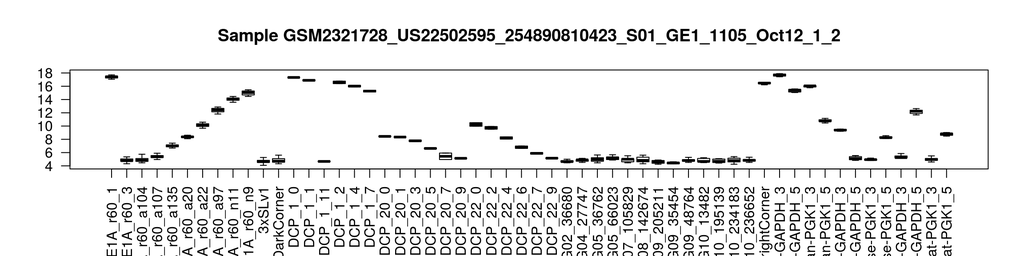

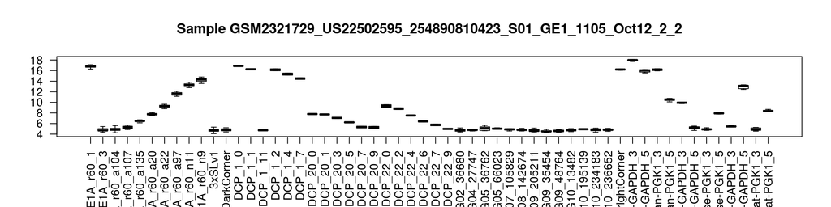

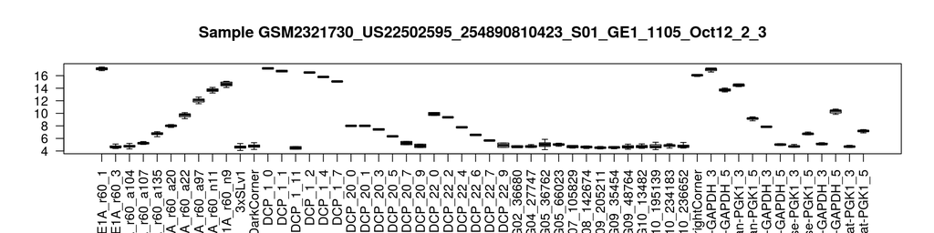

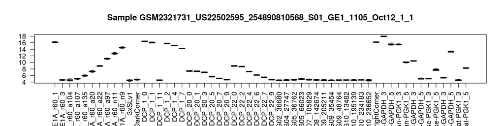

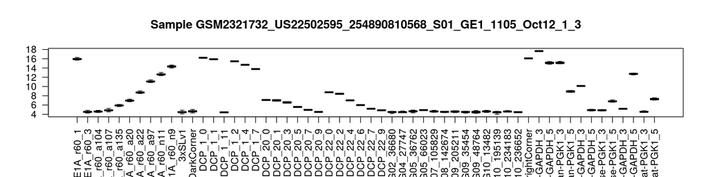

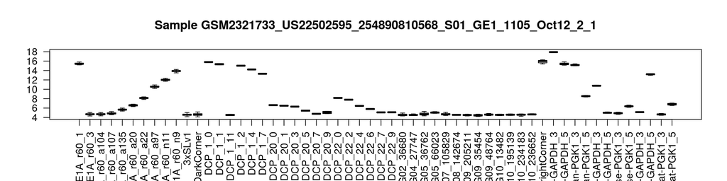

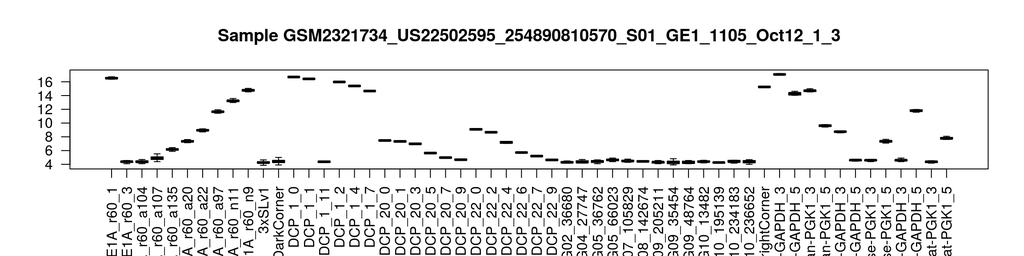

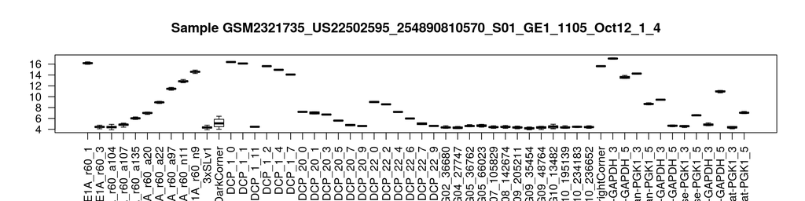

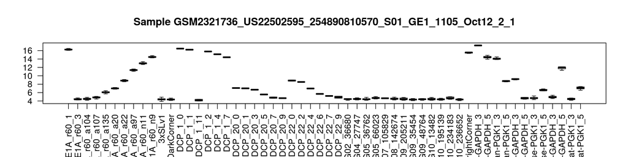

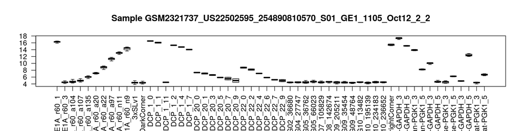

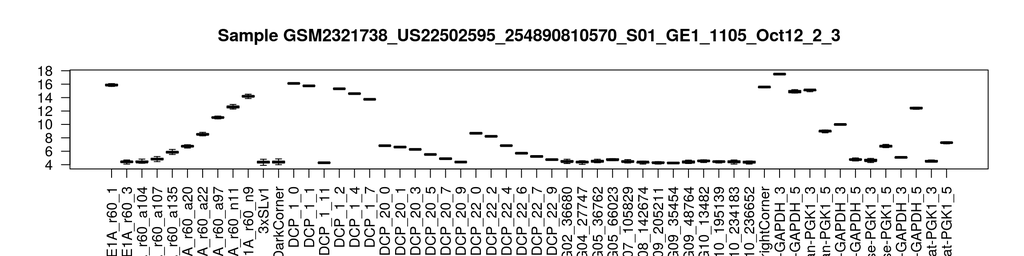

[4 more figures not shown]

```r
control_probes = which(intensities$genes$ControlType!=0)
cp_data = intensities$E[control_probes,]
cp_names = intensities$genes[control_probes,]
selected_controls = ifelse(substr(cp_names$ProbeName,1,4)=="ERCC",F,T)

# control probes
for (i in 1:ncol(cp_data)) {
  boxplot(log2(cp_data[selected_controls,i]) ~ factor(cp_names$ProbeName[selected_controls]),las=2, main=paste("Sample",colnames(cp_data)[i]), outline=F)
}
```

# 5 Number of detected probes

Signal for probes will be considered detected if the expression of a probe is above the 95% quantile of expression in negative control probes. In a typical experiment one would expect about 50% of all genes to be detectable.

```r
neg95 <- apply(normalized$E[normalized$genes$ControlType==-1,],2,function(x) quantile(x,p=0.95, na.rm=T))
cutoff <- matrix(1.1*neg95,nrow(normalized),ncol(normalized),byrow=TRUE)
isexpr <- rowSums(normalized$E > cutoff, na.rm=T) >= 2
# about 50% of genes should be detected
#table(isexpr)
```

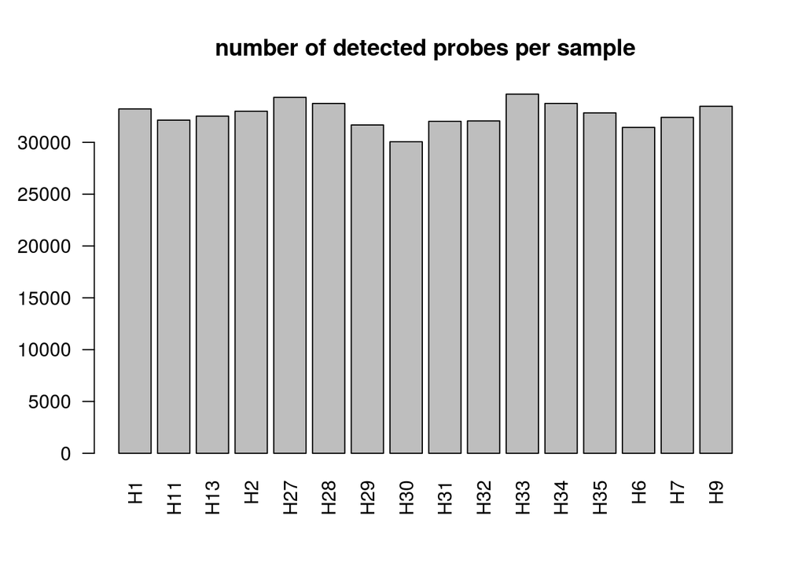

```r
isexpr_sample <- colSums(normalized$E > cutoff, na.rm=T)
sample_order = order(ed[names(isexpr_sample),]$scan_id)
isexpr_sample_ordered = isexpr_sample[sample_order]
nn = ed[names(isexpr_sample),]$sample_ID[sample_order]
barplot(isexpr_sample_ordered, main="number of detected probes per sample", las=2, names.arg=nn)
```

```r
data_folder = "../../Data/Preprocessed/"
save(ed, intensities, normalized, file=file.path(data_folder, "Human_micro_array_preprocessed_data.Rdata"))
```

# 6 Software versions